# 邏輯迴歸

wuyijin

2019年2月1日

# 邏輯迴歸

- 是與否的問題
  - 建立影響因素(X)與「是/否」(Y)的關係
  - 透過「條件機率」連結「影響因素」(X)與「是/否」(Y)
    - 機率的好處：完全相同的情境，也可能會有不同的結果
  - 透過大量個體資料，分析解釋變數如何影響是與否決策
- 乙狀函數 - 描述X與Y的關係
  - 為一介於(0,1)之間，嚴格遞增的可微分函數

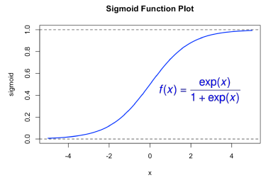

  - 使用乙狀函數描述解釋變數X與條件機率的關係

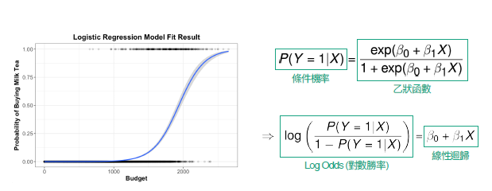

  - 勝率(Odds)代表成功機率與失敗機率的比值

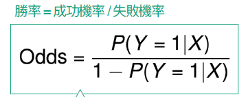

  - 對數勝率(Log Odds/Logit)與機率呈現乙狀關係

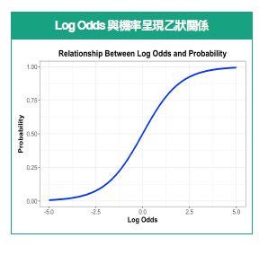

    - 解釋變數與條件機率呈現乙狀關係(邏輯迴歸的基本假設)
    - 對數勝率與條件機率呈現乙狀關係(對數勝率的數學性質)
    - 對數勝率與解釋變數呈現線性關係，且logit可為負，因此可以線性表達
- 最大概似法
  - 利用最大概似法估計邏輯迴歸的參數

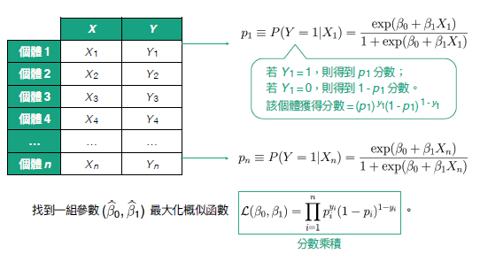

- 多元邏輯回歸模型：變數與待估計參數增加

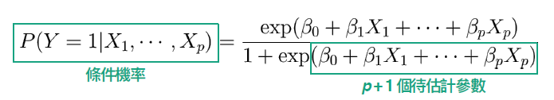

  - 如何確認是否β’s是否顯著不為0?
    - 假設檢定
      - 確認參數是否顯著異於0

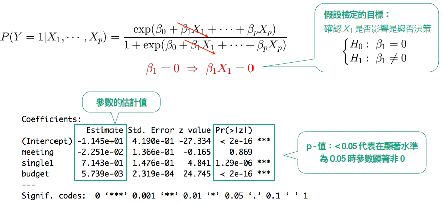

      - 解釋變數增加1單位將影響對數勝率、勝率、條件機率

  - 如何比較使用不同解釋變數X’s的模型?
    - 透過量化指標或是統計檢定進行模型比較

      |  | Pseudo R-Square | AIC / BIC | 極度比檢定 |
      | --- | --- | --- | --- |
      | 理論 | 比較目前模型與模型1 兩種模型捕捉資料資訊的能力 | 計算目前模型與真實模型時的 資訊落差，同時對變數量進懲罰 | 比較兩個不同模型(不同解釋變數X) 捕捉資料資訊的能力 |
      | 說明 | 越靠近1， 代表模型的解釋能力越好 | AIC/BIC越小， 資訊落差越小，解釋能力越好 | 若結果顯著， 代表傾向接受第一個模型 |

- 估計完個體機率後，根據設定的臨界機率進行分類

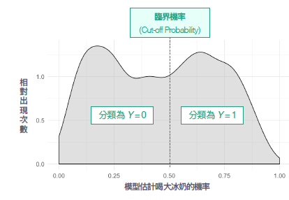

- 分類問題的模糊矩陣(Confusion Matrix)

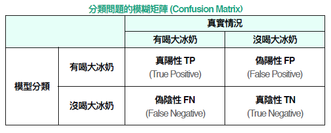

  - - 準確率(Accuracy)：衡量模型分類正確率

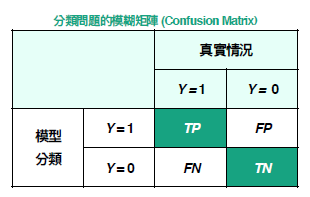

      - 指標定義:所有個體中，有多少比率的個體被分類正確?
      - 計算公式:Accuracy = (TP + TN) / (TP + FP + TN + FN)
    - 精確度(Precision)：避免模型誤判個體為陽性

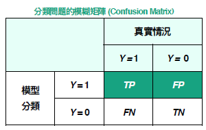

      - 指標定義:被模型分類為陽性的個體中，有多少比率確實為陽性?
      - 計算公式:Precision = TP / (TP + FP)
    - 召回度/敏感度(Recall/Sensitivity)：避免錯過任何一個陽性個體

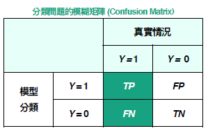

      - 指標定義:真正為陽性的個體中，有多少模型正確分類為陽性?
      - 計算公式:Recall = TP / (TP + FN)
    - 明確度(Specificity)：能夠準確分辨出陰性個體

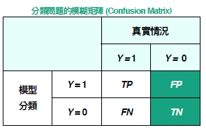

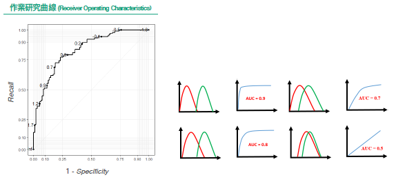

      - 由左而右代表臨界機率從1至0得到的(1-明確度,敏感度)
      - 曲線下面積(AUC)越靠近1，代表模型的分類效果越好，估計出來的機率越能夠分開資料